# Homework7

HudsonPlaskoff

2026-03-06

## Filter Diamonds Dataset[^1]

```r
diamonds_filtered <- diamonds %>%
  filter(
    color == "D" | color == "G" | color == "J",
    clarity == "I1" | clarity == "VS1" | clarity == "IF"
    )

diamonds_filtered_combinations <- diamonds_filtered %>%
  group_by(color,clarity) %>%
  summarize(n=n())
knitr::kable(diamonds_filtered_combinations)
```

| color | clarity | n |
| --- | --- | --- |
| D | I1 | 42 |
| D | VS1 | 705 |
| D | IF | 73 |
| G | I1 | 150 |
| G | VS1 | 2148 |
| G | IF | 681 |
| J | I1 | 50 |
| J | VS1 | 542 |
| J | IF | 51 |

## Visualization of Price and Carat

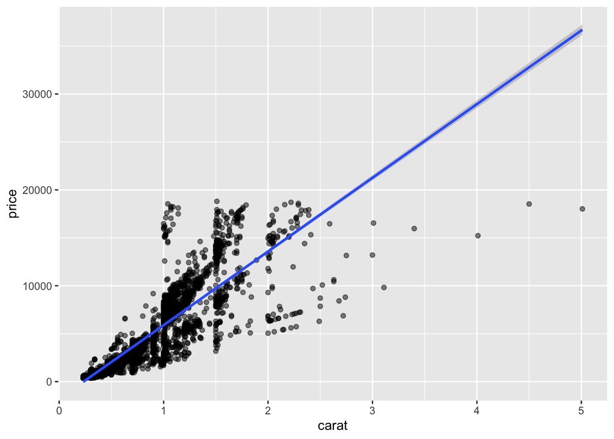

```r
ggplot(
  diamonds_filtered,
  aes(x=carat,y=price)
  ) +
  geom_point(alpha=0.5) +
  geom_smooth(method="lm")
```

There is a positive relationship between prices and carats for diamonds.[^2]

## Visualization of Price, Carat, and Color

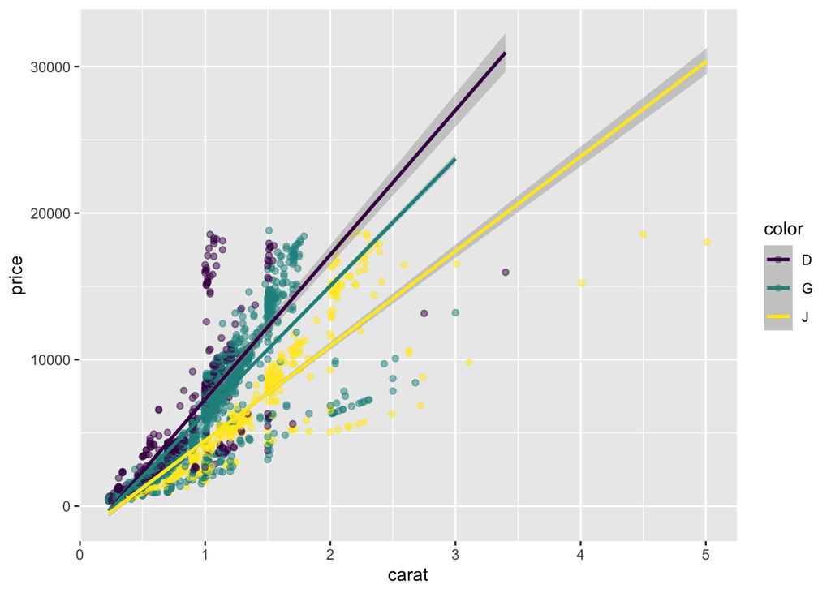

```r
ggplot(
  diamonds_filtered,
  aes(x=carat,y=price)
  ) +
  geom_point(alpha=0.5,aes(color=color)) +
  geom_smooth(method="lm",aes(color=color))
```

There is a positive relationship between prices and carats for diamonds, regardless of color. However, this relationship is most positive for D (best color), slightly less positive for G (middle-grade color), and even less positive for J (worst color).[^3]

## Visualization of Price, Carat, Color, and Clarity

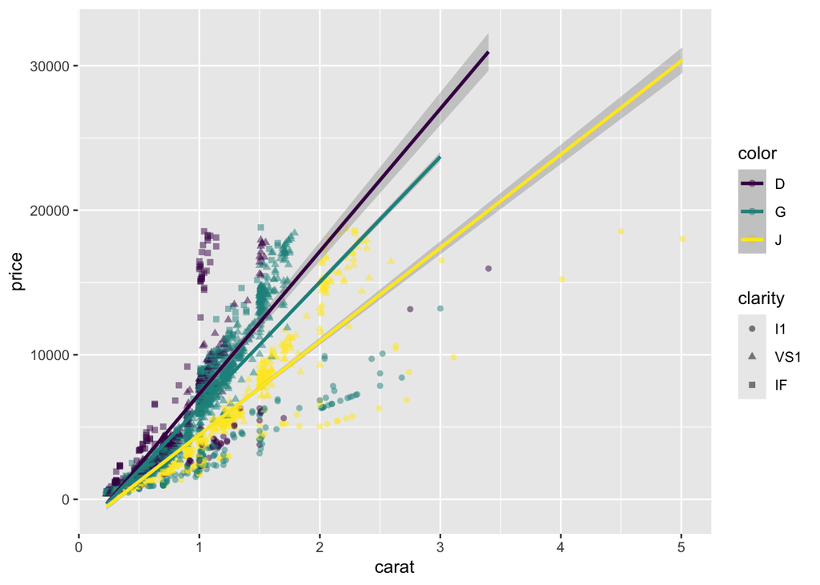

```r
ggplot(
  diamonds_filtered,
  aes(x=carat,y=price)
  ) +
  geom_point(alpha=0.5,aes(color=color,shape=clarity)) +
  geom_smooth(method="lm",aes(color=color))
```

This scatterplot is somewhat crowded, making it difficult to make any conclusive analysis of the data.[^4]

## Faceted Visualization of Price, Carat, Color, and Clarity

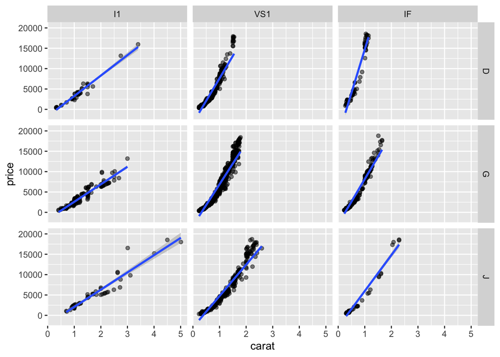

```r
ggplot(
  diamonds_filtered,
  aes(x=carat,y=price)
  ) +
  geom_point(alpha=0.5) +
  geom_smooth(method="lm") +
  facet_grid(color~clarity)
```

The steepest relationship is between IF (best clarity) and D (best color). As the color and clarity decrease respectively, the relationship becomes less positive, with the weakest (although still positive) relationship being between I1 (worst clarity) and J (worst color).[^5]

## Price-Carat Ratios of Color-Clarity Combinations

```r
diamonds_filtered <- diamonds_filtered %>%
  mutate(
    price_per_carat = price/carat
  ) %>%
  group_by(color,clarity) %>%
  summarize(price_per_carat = mean(price_per_carat)) %>%
  arrange(desc(price_per_carat))
knitr::kable(diamonds_filtered)
```

| color | clarity | price_per_carat |
| --- | --- | --- |
| D | IF | 9937.419 |
| G | VS1 | 4420.881 |
| D | VS1 | 4204.891 |
| G | IF | 4007.010 |
| J | VS1 | 3750.351 |
| J | IF | 3220.227 |
| D | I1 | 3064.485 |
| J | I1 | 2710.080 |
| G | I1 | 2617.478 |

[^1]: Question 1 complete
[^2]: Question 2 complete
[^3]: Question 3 complete
[^4]: Question 4 complete
[^5]: Question 5 complete
[^6]: Question 6 complete